# Visualisation avec

#### Diagramme en barres

**Afficher le code**

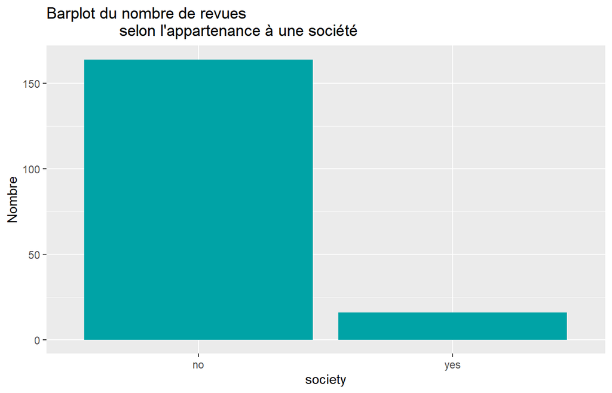

```r
# Barplot du nombre de revues
# selon l'appartenance à une société ('society')
ggplot(data = Journals) +
  aes(x = society) +
  geom_bar(fill = "#00a3a6") +   # couleur des barres
  # ajout du titre et des labels
  labs(title = "Barplot du nombre de revues
                selon l'appartenance à une société",
       x = "society",
       y = "Nombre")
```

### Exemple de mise en forme plus avancée d’un graphique avec [{ggplot2}](https://ggplot2.tidyverse.org/)

**Afficher le code**

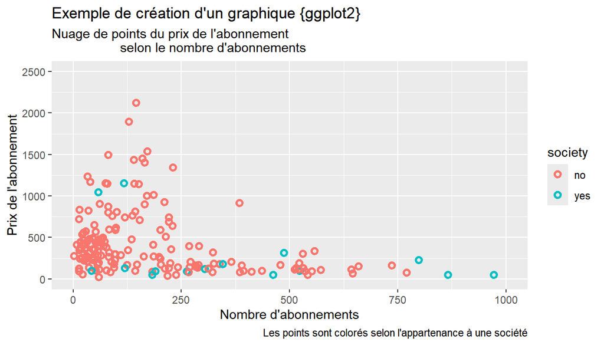

```r
ggplot(data = Journals) +    # initialisation du graphique
  aes(x = oclc,              # variable en abscisse
      y = libprice,          # variable en ordonnée
      colour = society) +    # points colorés selon les valeurs de 'society'
  geom_point(shape = 1,      # type de symbole
             size = 1.5,     # taille des symboles
             stroke = 1.5) + # épaisseur de la bordure des symboles
  scale_x_continuous(limits = c(0, 1000)) + # limites de l'axe des x
  scale_y_continuous(limits = c(0, 2500),   # limites de l'axe des y
                     breaks = seq(from = 0, to = 2500, by = 500)) +  # graduations de l'axe des y
  labs(title = "Exemple de création d'un graphique {ggplot2}",  # titre du graphique
       subtitle = "Nuage de points du prix de l'abonnement
                   selon le nombre d'abonnements",  # sous-titre
       x = "Nombre d'abonnements",  # titre pour l'axe des x
       y = "Prix de l'abonnement",  # titre pour l'axe des y
       caption = "Les points sont colorés selon l'appartenance à une société") # légende
```

### Sauvegarde des graphiques créés avec [{ggplot2}](https://ggplot2.tidyverse.org/)

- Utilisation de la fonction `ggsave()` du package [{ggplot2}](https://ggplot2.tidyverse.org/) à la fin de la création du graphique pour l’enregistrer

```r
# Sauvegarde du graphique
ggplot(...) +
  ...
ggsave(filename = name.extension,
       device = NULL)
```

**AstuceLes formats d’enregistrement possibles**

- png
- jpeg
- tiff
- bmp
- svg
- eps
- ps
- pdf
- tex
- Le format du graphique peut être précisé dans le paramètre `device`  
  Si `device = NULL`, le type de graphique est déterminé automatiquement en fonction de l’extension du nom du fichier
- La taille (`width` et `height`), ainsi que la résolution (`dpi`) peuvent être paramétrées

### Vous n’êtes pas à l’aise pour réaliser un graphique [{ggplot2}](https://ggplot2.tidyverse.org/) ?

Une interface “clic bouton”, avec la possibilité de récupérer les lignes de code, peut vous aider [{esquisse}](https://github.com/dreamRs/esquisse)

- Commande pour lancer [{esquisse}](https://github.com/dreamRs/esquisse)

```r
esquisse::esquisser()
```

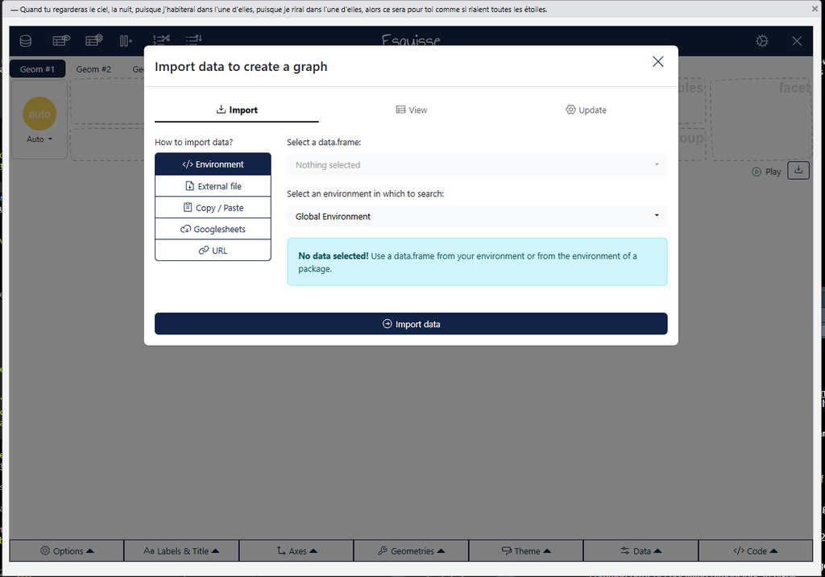

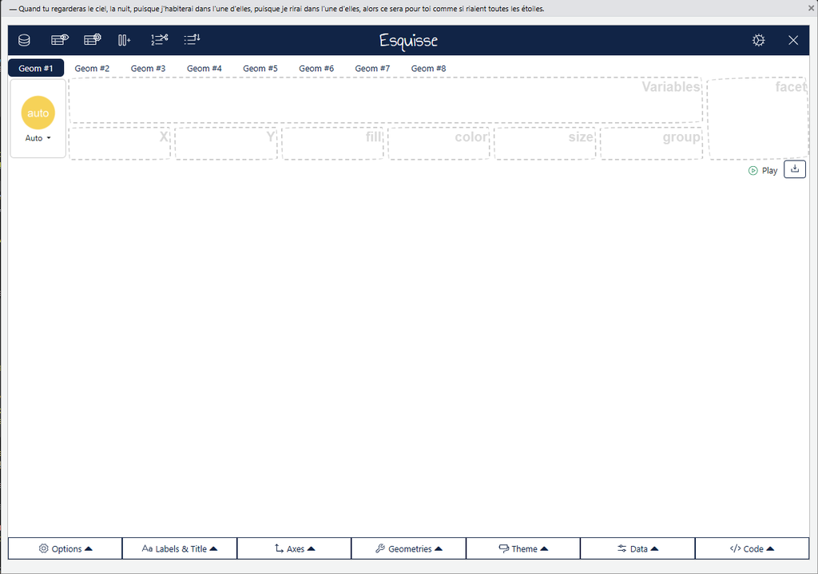

### Un site pour aider à trouver la représentation la plus appropriée aux données

[interactive chart not shown]

Site : [from Data to Viz](https://www.data-to-viz.com/)

## À VOUS DE JOUER !

**Exercice 3** **Construire des graphiques avec `{ggplot2}` à partir du jeu de données `communes`**

Compléter le script **`01_Exercices_VisuR.R`** du projet **VisuR_exercices** pour créer les graphiques suivants :

1. un diagramme en barres pour visualiser la distribution de la variable ‘region’  
   *Pour ce graphique on choisit de colorer les barres en bleu*
2. un histogramme pour visualiser la distribution de la variable de surface_urbaine pour l’année 2020  
   *Choisir un nombre ou une largeur de classes pertinents pour pouvoir interpréter le graphique*
3. un boxplot du taux de chômage selon l’année  
   *Pour ce graphique, on choisit de colorer les boîtes en fonction de l’année*
4. Sauvegarder ce graphique dans le dossier adéquat, en `png`

**Les graphiques doivent comporter toutes les informations utiles (étiquettes) pour faciliter leur compréhension**

*Solution 3*. **Script 01_Exercices_VisuR.R**

**Afficher le code**

```r
#   ____________________________________________________________________________
#   Exercice sur les graphiques ggplot2                                     ####

# 01. Diagramme en barres - variable 'region'
ggplot(data = communes) +      # initialisation du graphique
  aes(x = region) +            # variable à représenter
  geom_bar(fill = "blue") +    # type de graphique = barplot ; couleur des barres
  # Ajout du titre, des étiquettes des axes et de la source des données
  labs(title = "Distribution de la variable 'region'",
       x = "Région",
       y = "Effectifs",
       caption = "Source : données fictives 'communes'")

# Le graphique n'est pas très lisible
# On peut tracer le graphique avec des barres horizontales, en remplaçant x par y dans aes() :
ggplot(data = communes) +
  aes(y = region) +
  geom_bar(fill = "blue")

# 02. Histogramme - variable 'surface_urbaine'
# a. On regarde la distribution de la variable
communes |>
  select(surface_urbaine) |>
  summary()
# b. On trace l'histogramme, avec des classes d'amplitude 1000
ggplot(data = communes |>
                filter(annee == 2020)) +   # initialisation du graphique
  aes(x = surface_urbaine) +               # variable à représenter
  geom_histogram(binwidth = 1000) +        # type de graphique = histo ; amplitude des classes
  # Ajout du titre, des étiquettes des axes et de la source des données
  labs(title = "Distribution de la variable 'surface_urbaine'",
       x = "Superficie (ha)",
       y = "Effectifs",
       caption = "Source : données fictives 'communes'")

# 03. Boxplot - variable 'taux_chomage' x 'annee'
ggplot(data = communes |>                     # initialisation du graphique
         mutate(annee = as.factor(annee))) +  # transformation de 'annee' en facteur, pour avoir une boîte par modalité
  aes(x = annee,                              # variable en abscisse
      y = taux_chomage,                       # variable en ordonnée
      fill = annee) +                         # variable pour assigner une couleur aux boîtes
  geom_boxplot() +                            # type de graphique = boxplot
  # Ajout du titre, des étiquettes des axes et de la source des données
  labs(title = "Distribution du taux de chômage selon l'année",
       x = "Année",
       y = "Taux de chômage (%)",
       caption = "Source : données fictives 'communes'")
# 04. Sauvegarde du graphique
ggsave("plots/boxplot_CHOMAGExAN.png")  # dossier / nom du graphique.extension
```

# Séance 3 - Visualisations avancées et approfondissement {ggplot2}

## Préparation des données pour les graphiques

### Résumer et grouper les données avec le package [{dplyr}](https://dplyr.tidyverse.org/)

#### `summarise()` : créer un tableau contenant des statistiques agrégées (moyenne, somme, minimum, maximum, etc.), pour une ou plusieurs variables

##### Une variable et un indicateur

**Afficher le code**

```r
# Valeur la plus faible de 'libprice'
Journals |>
  summarise(min(libprice))
```

```
  min(libprice)
1            20
```

##### Plusieurs variables et un indicateur

**Afficher le code**

```r
# Valeur médiane de chaque variable numérique
# dont le nom contient le caractère "p"
Journals |>
  select(where(is.numeric)) |>
  summarise(across(contains("p"), median))
```

```
  libprice pages charpp
1      282   693   3010
```

**Afficher le code**

```r
# Moyenne de chaque variable numérique de `Journals`
Journals |>
  summarise(across(where(is.numeric),
                   ~ mean(.x, na.rm = TRUE)))
```

```
  libprice    pages charpp citestot    date1 anciennete     oclc
1 417.7222 827.7444 3232.7 647.0556 1966.906   59.09444 196.8667
```

##### Une variable et plusieurs indicateurs

**Afficher le code**

```r
# Calcul de plusieurs indicateurs pour 'libprice'
Journals |>
  summarise(moyenne = mean(libprice, na.rm = TRUE),
            ecartType = sd(libprice),
            mediane = median(libprice, na.rm = TRUE))
```

```
   moyenne ecartType mediane
1 417.7222  385.8346     282
```

##### Plusieurs variables et plusieurs indicateurs

**Afficher le code**

```r
# Calcul de plusieurs indicateurs pour 'libprice' et 'oclc'
Journals |>
  summarise(across(c(libprice, oclc),
                   list(moyenne = mean,
                        ecartType = sd)))
```

```
  libprice_moyenne libprice_ecartType oclc_moyenne oclc_ecartType
1         417.7222           385.8346     196.8667       204.5288
```

Avec `summarise(across())`, les noms des nouvelles variables sont créés en concaténant les noms des variables initiales et les noms des fonctions indiqués dans `list()`, séparés par un `_`

**AstuceExemples de fonctions couramment utilisées dans la fonction `summarise()`**

- `n()` : nombre de lignes
- `min(x, na.rm = TRUE)` : minimum
- `max(x, na.rm = TRUE)` : maximum
- `sum()` : somme
- `mean(x, na.rm = TRUE)` : moyenne
- `sd(x, na.rm = TRUE)` : écart-type
- `median(x, na.rm = TRUE)` : médiane
- `quantile(x, na.rm = TRUE)` : quantiles
- `IQR(x, na.rm = TRUE)` : intervalle interquartiles
- `n_distinct()` : nombre de valeurs distinctes

#### `group_by()` : définir des groupes à partir des modalités d’une variable catégorielle du jeu de données

Une fois les groupes définis, on peut appliquer des opérations sur ces groupes (`mutate()`, `filter()`, `summarise()`, etc.)

**Afficher le code**

```r
# Comparaison des citations selon 'society'
Journals |>
  # Groupes selon les modalités de 'society' (no/yes)
  group_by(society) |>
  # Calcul de la moyenne par groupe
  # --> réduit chaque groupe à une ligne (= moyenne)
  summarise(citestot.mean = mean(citestot,
                                 na.rm = TRUE))
```

```
# A tibble: 2 × 2
  society citestot.mean
  <fct>           <dbl>
1 no               516.
2 yes             1991.
```

Très utile pour des graphiques par groupes

**Afficher le code**

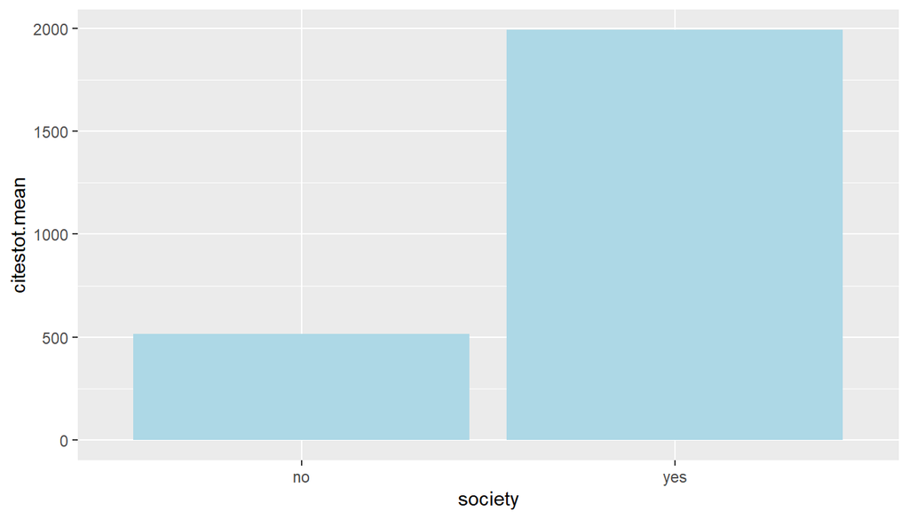

```r
# Calcul de l'indicateur par groupe
Journals |>
  group_by(society) |>
  summarise(citestot.mean = mean(citestot,
                                 na.rm = TRUE)) |>
# Graphique
  ggplot() +
  aes(x = society, y = citestot.mean) +
  geom_col(fill = "lightblue")
```

- On peut grouper selon plusieurs variables

**Afficher le code**

```r
# Calcul de la moyenne de 'citestot'
# en fonction des variables
# - 'society'
# - 'field' (uniquement les modalités Econometrics et Finance)
Journals |>
  # Sélection des 2 domaines
  filter(field %in% c("Econometrics", "Finance")) |>
  # Groupes
  group_by(society, field) |>
  # Moyenne pour chacun des 4 groupes (2 x 2)
  summarise(citestot.mean = mean(citestot, na.rm = TRUE))
```

```
# A tibble: 4 × 3
# Groups:   society [2]
  society field        citestot.mean
  <fct>   <fct>                <dbl>
1 no      Econometrics          842.
2 no      Finance               487.
3 yes     Econometrics         2800
4 yes     Finance              3791
```

- Pour annuler la structuration en groupes, on utilise la fonction `ungroup()`

### Manipulations avec le package [{tidyr}](https://tidyr.tidyverse.org/)

#### Le concept de données `tidy`

- **Un jeu de données `tidy` (“rangé”) est un jeu de données où**
  - chaque variable est dans une colonne
  - chaque observation est dans une ligne
  - chaque valeur est dans une cellule

Source : Wickham & Grolemund (2018)

- Les jeux de données ne respectent pas toujours ces règles
  - en-têtes de colonnes ne sont pas des noms mais des valeurs
  - plusieurs variables stockées dans une colonne
  - variables stockées dans les lignes et les colonnes
  - plusieurs types d’observations stockés dans le même tableau, etc.

**On peut ranger les données avec les verbes de [{tidyr}](https://tidyr.tidyverse.org/)**  
- `pivot_longer()` : du format large au format long  
- `pivot_wider()` : du format long au format large

Les fonctions du package [{tidyr}](https://tidyr.tidyverse.org/) sont disponibles dans la [*cheatsheet*](https://rstudio.github.io/cheatsheets/html/tidyr.html) du package

**NoteFormat large, format long : quelle différence ?**

- **Format large** : une variable = une colonne

Format large (données de population)

| pays | 2019 | 2020 | 2021 |
| --- | --- | --- | --- |
| France | 67 144 101 | 67 287 241 | 67 407 241 |

- **Format long** : une ligne = une observation d’une variable

Format long

| pays | année | valeur |
| --- | --- | --- |
| France | 2019 | 67 144 101 |
| France | 2020 | 67 287 241 |
| France | 2021 | 67 407 241 |

#### `pivot_longer()` : passer du format large à long

Fonction qui convertit plusieurs colonnes en deux nouvelles colonnes : une pour les noms des variables ; une pour leurs valeurs correspondantes

**Réduit le nombre de colonnes mais augmente celui des lignes**, rendant ainsi le jeu de données plus “long”

**Afficher le code**

```r
Journals_long <- Journals |>
  mutate(ID = seq(1:nrow(Journals))) |> # ajout d'une variable ID (1 n° = 1 journal)
  select(ID, title, libprice, pages, charpp) |> # sélection des variables pour une meilleure lisibilité de cet exemple
  pivot_longer(cols = c(libprice, pages, charpp), # colonnes à pivoter
               names_to = "variable", # nom de la colonne du format long qui contiendra les anciens noms de colonnes du format large
               values_to = "valeur")  # nom de la colonne du format long qui contiendra les anciennes valeurs du format large

Journals_long
```

```
# A tibble: 540 × 4
      ID title                                               variable valeur
   <int> <fct>                                               <chr>     <int>
 1     1 Asian-Pacific Economic Literature                   libprice    123
 2     1 Asian-Pacific Economic Literature                   pages       440
 3     1 Asian-Pacific Economic Literature                   charpp     3822
 4     2 South African Journal of Economic History           libprice     20
 5     2 South African Journal of Economic History           pages       309
 6     2 South African Journal of Economic History           charpp     1782
...
```

**Particulièrement utile pour restructurer les données pour les analyses statistiques ou représentations graphiques qui nécessitent un format long**

##### Exemple d’utilisation dans un graphique

**Afficher le code**

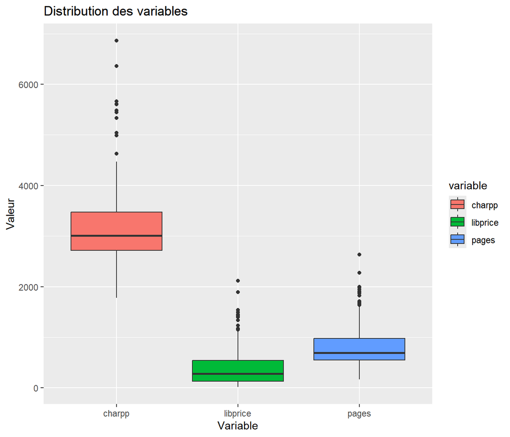

```r
ggplot(data = Journals_long) +
  aes(x = variable, y = valeur, fill = variable) +
  geom_boxplot() +
  labs(title = "Distribution des variables",
       x = "Variable",
       y = "Valeur")
```

#### `pivot_wider()` : passer du format long à large

Fonction qui transforme les données du format long au format large (*wide*)

**Afficher le code**

```r
Journals_long |>
  pivot_wider(names_from = variable, # colonne du format long dont les valeurs deviendront des noms de colonnes du format large
              values_from = valeur) # colonne du format long dont les valeurs rempliront les cellules du format large
```

```
# A tibble: 180 × 5
      ID title                                             libprice pages charpp
   <int> <fct>                                                <int> <int>  <int>
 1     1 Asian-Pacific Economic Literature                      123   440   3822
 2     2 South African Journal of Economic History               20   309   1782
 3     3 Computational Economics                                443   567   2924
 4     4 MOCT-MOST Economic Policy in Transitional Econom…      276   520   3234
 5     5 Journal of Socio-Economics                             295   791   3024
 6     6 Labour Economics                                       344   609   2967
 7     7 Environment and Development economics                   90   602   3185
 8     8 Review. of Radical Political Economics                 242   665   2688
 9     9 Economics of Planning                                  226   243   3010
10    10 Metroeconomica                                         262   386   2501
# ℹ 170 more rows
```